# dgevbhm vignette

In this vignette, we present an example workflow to apply our R code for fitting the duration-dependent Generalized Extreme Value distribution (dGEV) in a Bayesian Hierarchical framework (Rischmuller et al. 2026). We use sub-daily precipitation records from the Global Sub-Daily Rainfall dataset (Lewis et al. 2019) over the United Kingdom.

```r
library(dgevbhm)
```

To reproduce this workflow on your own machine, you will first need to obtain the raw sub-daily precipitation text files (e.g., from the Global Sub-Daily Rainfall dataset). Please download the data and place the files into a local directory on your computer.

Once your directory is set up, you can read the data into R by pointing the `dir_path` argument to your chosen folder:

```r
# Replace "/path/to/directory/" with the actual path where you saved the data
UK_data_full <- data_read(dir_path = "/path/to/directory/",
                          missing_data = 5,
                          durs = c(1, 3, 6, 12, 24, 48),
                          cores = 4)
```

(Note: For this vignette, the processed UK_data_full object is already bundled and loaded with the package.)

```r
length(UK_data_full$y)
```

```
#> [1] 47
```

Out of 1903 files, 47 stations were selected based on the requirements mentioned above.

## Selecting the rain gauges

`dgev_bhm()` is the central function of our package. It is able to fit the Bayesian Hierarchical dGEV models for a chosen sample of rain gauges. There, the user can choose if the shape parameter of the dGEV is fixed over durations (resulting in the same shape parameter for all durations, $\xi_d$) or fixed over space (resulting in the same shape parameter for all rain gauges, $\xi_j$).

```r
# mean and median hourly precipitation rate (mm)
mean(UK_data_full$amp)
```

```
#> [1] 0.1024251
```

```r
median(UK_data_full$amp)
```

```
#> [1] 0.0882582
```

Below we show an example of selecting similar stations using annual mean precipitation `amp`:

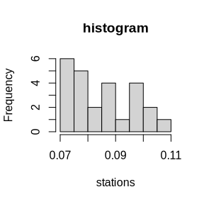

```r
med_amp <- median(UK_data_full$amp)
# similar stations: selection of 25 stations that are closest to the median precipitation rate
sim_stations <- which(rank(abs(UK_data_full$amp - med_amp)) <= 25)
# plotting a histogram of the 25 precipitation rates
hist(UK_data_full$amp[sim_stations], main = 'histogram', xlab = 'stations')
```

```r
names(UK_data_full) #checking header of the GSDR data
```

```
#> [1] "y"         "amp"       "latlon"    "stationID" "durs"
```

```r
dim(UK_data_full$latlon) #dimension of the latlon
```

```
#> [1] 47  2
```

```r
# clean the data: select the 25 rain gauges and store them in a new object
UK_data <- list()
UK_data$y <- UK_data_full$y[sim_stations]
UK_data$amp <- UK_data_full$amp[sim_stations]
UK_data$latlon <- UK_data_full$latlon[sim_stations, ]
UK_data$stationID <- UK_data_full$stationID[sim_stations]
# don't forget the durations!
UK_data$durs <- c(1, 3, 6, 12, 24, 48)
```

## Fit the Bayesian hierarchical models

```r
# Fit the dGEV-BHM with the shape parameter fixed over durations (shp_d = 'd'). We opt for 2000 iterations of the MCMC sampler, where the first half is used as burn-in.
# We assume that 2 cores are available for computation.
# As you can only use one core per chain, we use 2 chains.

# WARNING: May take some time. You can also load the prepared fitted models.
fit_xi_d <- dgev_bhm(data = UK_data, chains = 2, iter = 2000, cores = 2, shp_d = 'd')
```

```
#>
#> Computing initial parameters... Complete!
#>
#> Loading pre-compiled Stan model (durational)... Complete!
#>
#>
```

```r
# Fit the dGEV-BHM with the shape parameter fixed over space (shp_d = 'j').

# WARNING: May take some time. You can also load the prepared fitted models.
fit_xi_j <- dgev_bhm(data = UK_data, chains = 2, iter = 2000, cores = 2, shp_d = 'j')
```

```
#>
#> Computing initial parameters... Complete!
#>
#> Loading pre-compiled Stan model (spatial)... Complete!
#>
#>
```

```r
# structure of the fitted models
names(fit_xi_d)
```

```
#>  [1] "pars"                 "data"                 "information_criteria"
#>  [4] "mcmc_diagnostics"     "durs"                 "j"
#>  [7] "d"                    "shp_d"                "mcsamp"
#> [10] "stationID"
```

```r
names(fit_xi_j)
```

```
#>  [1] "pars"                 "data"                 "information_criteria"
#>  [4] "mcmc_diagnostics"     "durs"                 "j"
#>  [7] "d"                    "shp_d"                "mcsamp"
#> [10] "stationID"
```

There are 10 list items in the fitted model:

- `pars` – posterior parameters samples
- `data` – original input data
- `information_criteria`
  1. widely applicable information criteria
  2. leave-one-out information criteria
- `mcmc_diagnostics`
  1. R-hat
  2. Effective sample size
- `durs` – duration vector of the model
- `j` – number of localities
- `d` – number of durations
- `shp_d` – hierarchical dimension with respect to space `"j"` or durations `"d"`
- `mcsamp` – MCMC sample size
- `stationID` – vector of station IDs

## Bayesian summary statistics

From the fitted `dgev_bhm()` object, we can obtain MCMC convergence diagnostics.

Here for the parameter $\tilde{\mu}$:

```r
# MCMC diagnostics for mut
fit_xi_d$mcmc_diagnostics$rhat$mut
```

```
#>    mut[1]    mut[2]    mut[3]    mut[4]    mut[5]    mut[6]    mut[7]    mut[8]
#> 1.0000403 0.9991269 0.9991997 0.9992323 0.9995417 0.9990218 0.9994541 1.0007062
#>    mut[9]   mut[10]   mut[11]   mut[12]   mut[13]   mut[14]   mut[15]   mut[16]
#> 0.9997632 0.9993412 0.9993566 0.9992956 0.9991685 1.0007150 0.9992263 0.9991222
#>   mut[17]   mut[18]   mut[19]   mut[20]   mut[21]   mut[22]   mut[23]   mut[24]
#> 0.9991623 1.0004622 0.9994977 0.9990699 1.0004650 0.9991289 0.9995456 0.9992196
#>   mut[25]
#> 0.9990264
```

```r
fit_xi_d$mcmc_diagnostics$ess$mut
```

```
#>   mut[1]   mut[2]   mut[3]   mut[4]   mut[5]   mut[6]   mut[7]   mut[8]
#> 3093.929 4018.068 4005.047 3585.580 3665.575 2618.794 3883.642 3251.253
#>   mut[9]  mut[10]  mut[11]  mut[12]  mut[13]  mut[14]  mut[15]  mut[16]
#> 3225.260 3710.590 3347.668 2769.875 3139.339 3238.760 2931.730 3765.803
#>  mut[17]  mut[18]  mut[19]  mut[20]  mut[21]  mut[22]  mut[23]  mut[24]
#> 4239.134 3258.273 3671.694 4226.299 3774.721 3420.278 3102.722 4157.908
#>  mut[25]
#> 3342.002
```

### Information criteria

Examine out-of-sample predictive accuracy with information criteria (IC).

```r
fit_xi_j$information_criteria
```

```
#> $waic
#>             Estimate        SE
#> elpd_waic -5763.3264  82.86389
#> p_waic      110.0079   4.13938
#> waic      11526.6528 165.72778
#>
#> $looic
#>            Estimate         SE
#> elpd_loo -5764.9707  82.950855
#> p_loo      111.6522   4.377932
#> looic    11529.9414 165.901709
```

```r
fit_xi_d$information_criteria
```

```
#> $waic
#>             Estimate         SE
#> elpd_waic -5785.6666  83.562473
#> p_waic       95.7863   4.266617
#> waic      11571.3332 167.124946
#>
#> $looic
#>             Estimate         SE
#> elpd_loo -5786.41045  83.594353
#> p_loo       96.53016   4.382629
#> looic    11572.82089 167.188706
```

The dGEV-BHM-$\xi_j$ is the better model, because the IC values are lower, indicating superior out-of-sample predictive accuracy.

## Checking the model fits

Now we will proceed with goodness-of-fit metrics.

Probability-probability plots:

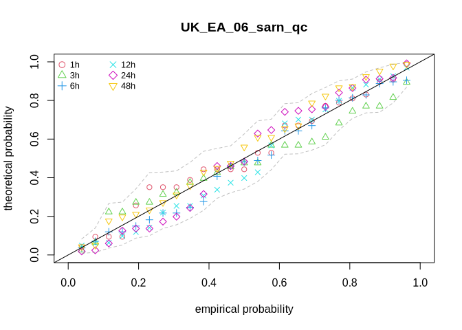

```r
pp_plot(fit = fit_xi_d, j = 5)
```

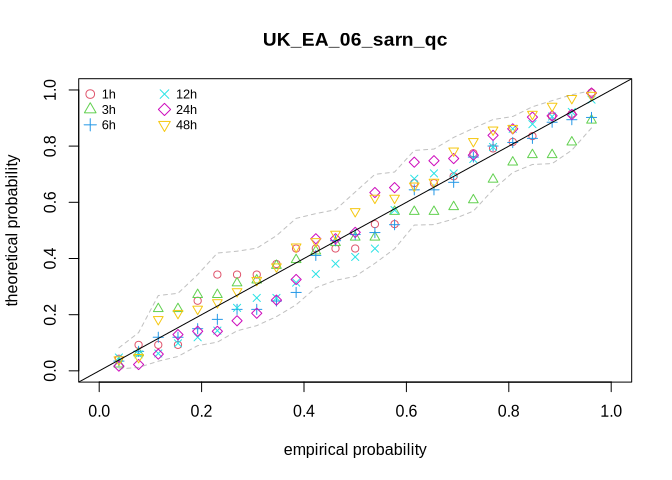

```r
pp_plot(fit = fit_xi_j, j = 5)
```

Ideally, the dots should line up close to the 1:1 diagonal. Furthermore, no single duration should deviate significantly, as this could indicate that the dGEV model is inappropriate for capturing duration dependence. While both models yield visually similar results in the PP-plots, the information criteria previously established that dGEV-BHM-$\xi_j$ provides a better overall fit for this dataset.

### Posterior predictive metrics

The figures below generated by the `post_pred_plot` function are posterior predictive histograms. The histogram generates the theoretical statistic (e.g., quantiles, median, max, min) of the posterior parameter samples. In our case, the statistics are computed using the GEV itself. We compare this with the empirical statistic from the data sample. With this, we get a sense of the goodness of fit as well as the uncertainty.

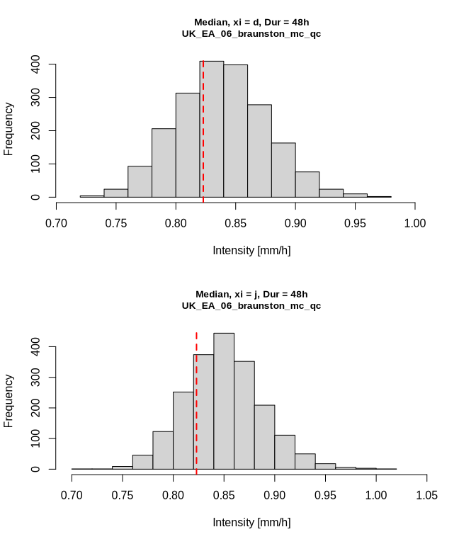

```r
par(mfrow = c(2, 1))
post_pred_plot(fit = fit_xi_d, stat = 'median', j = 1, d = 6) # posterior predictive diagnostic plot for rain gauge #1 and duration 48h for the fit_xi_d model
post_pred_plot(fit = fit_xi_j, stat = 'median', j = 1, d = 6) # posterior predictive diagnostic plot for rain gauge #1 and duration 48h for the fit_xi_j model
```

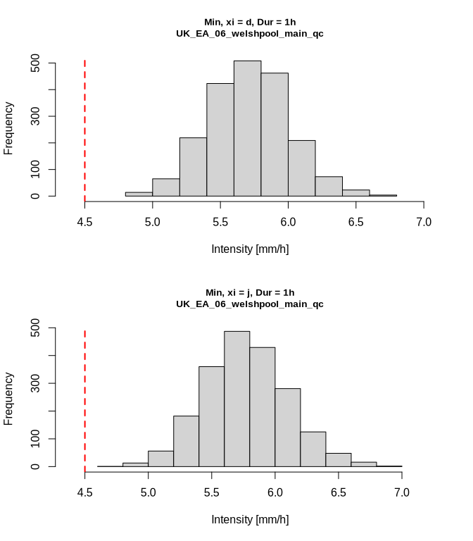

```r
par(mfrow = c(2, 1))
post_pred_plot(fit = fit_xi_d, stat = 'min', j = 6, d = 1) # posterior predictive diagnostic plot for rain gauge #6 and duration 1h for the fit_xi_d model
post_pred_plot(fit = fit_xi_j, stat = 'min', j = 6, d = 1) # posterior predictive diagnostic plot for rain gauge #6 and duration 1h for the fit_xi_j model
```

In the posterior predictive histograms, not all stations are going to fit perfectly. This is especially, and almost exclusively, true for `'min'` and `'max'` statistics. This is due to the asymptotic nature of the GEV, which models the limit of block extremes (the histogram) and therefore often fails to capture a single, rare absolute record (the red line) in a finite sample.

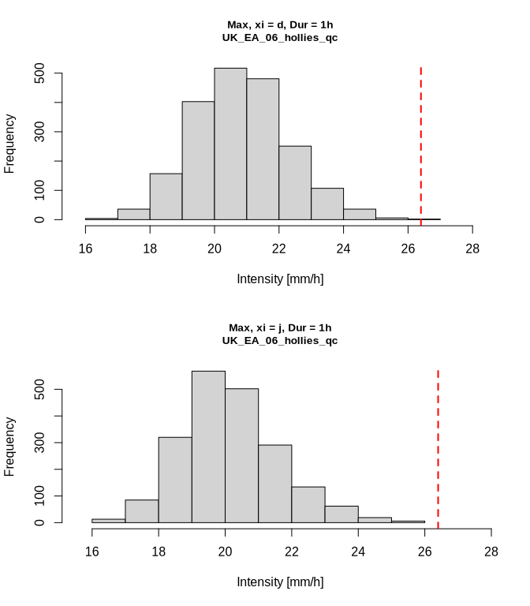

```r
par(mfrow = c(2, 1))
post_pred_plot(fit = fit_xi_d, stat = 'max', j = 3, d = 1)
post_pred_plot(fit = fit_xi_j, stat = 'max', j = 3, d = 1)
```

Instead of using a diagram, we can calculate the posterior predictive p-value using the `post_pred_pval()` function. The inputs are identical to the `post_pred_plot()` function. An ideal fit for the model would yield a p-value of 0.5.

```r
post_pred_pval(fit = fit_xi_d, stat = 'median', j = 2, d = 6)
```

```
#> [1] 0.26
```

```r
post_pred_pval(fit = fit_xi_j, stat = 'median', j = 2, d = 6)
```

```
#> [1] 0.3195
```

While p-values can fluctuate across different gauge samples, the dGEV-BHM-$\xi_j$ model’s median aligns with the quantitative information criteria results, demonstrating a reliable and superior fit for this specific spatial sample.

## Return level plots

The inputs are:

- `j` - spatial locality
- `d` - duration
- `max_rp` - maximum plotted return period
- `alpha` - significance level for credible intervals (default `alpha=0.05`)

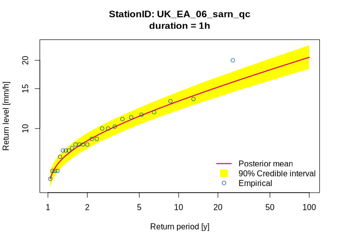

```r
# let's try a significance level of 0.1
return_level_plot(fit_xi_d, j = 5, d = 1, max_rp = 100, alpha = 0.1)
```

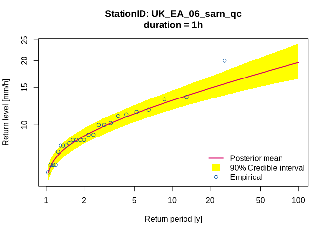

```r
return_level_plot(fit_xi_j, j = 5, d = 1, max_rp = 100, alpha = 0.1)
```

## Intensity-duration-frequency curves

The inputs are:

- `j` - spatial locality
- `rp` - return periods (i.e. frequency)
- `alpha` - significance level for credible intervals (default `alpha=0.05`)

Here we have a single IDF curve on the plot:

```
#> Computing d-dimensional shape IDF curve...
```

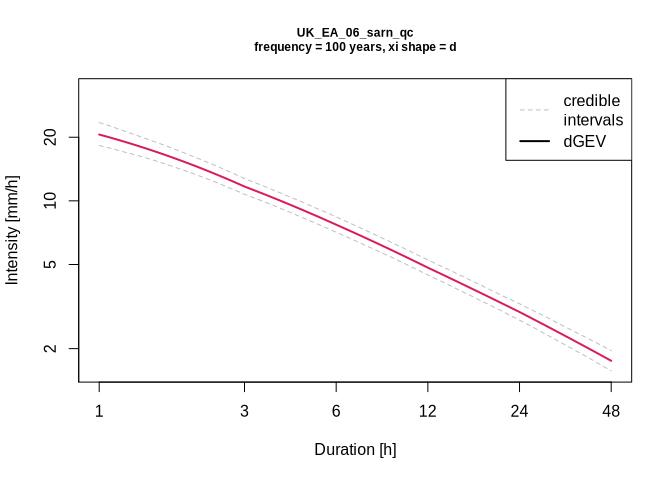

```r
idf_plot(fit = fit_xi_d,j = 5, rp = 100, alpha = 0.05)
```

Multiple IDF curves on the plot:

```
#> Computing d-dimensional shape IDF curve...
```

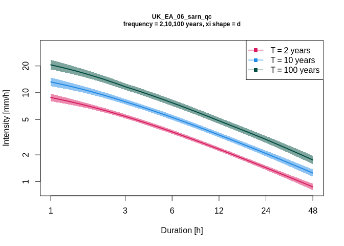

```r
idf_plot(fit = fit_xi_d,j = 5, rp = c(2,10,100), alpha = 0.05)
```

The IDF curves are the final result, and they can be produced for all 25 rain gauges, where the user can select return period(s) and the confidence interval. Rischmuller et al. (2026) have shown the added value of the dGEV Bayesian Hierarchical estimation compared to standard station-wise GEV or dGEV-MLE estimations in terms of higher accuracy and robustness.

Lewis, Elizabeth, Hayley Fowler, Lisa Alexander, et al. 2019. “GSDR: A Global Sub-Daily Rainfall Dataset.” *Journal of Climate* 32 (15): 4715–29.

Rischmuller, Alexander Lee, Benjamin Poschlod, and Jana Sillmann. 2026. “Bayesian Hierarchical Modelling of Intensity-Duration-Frequency Curves Using a Climate Model Large Ensemble.” *Advances in Statistical Climatology, Meteorology and Oceanography* 12 (1): 1–19.